# `phydms` Tutorial

In this tutorial you will learn the basics of [`phydms`](http://jbloomlab.github.io/phydms/index.html). We will walk through examples of analyses you may want to run to compare your deep mutational scanning data to natural sequence evolution. For more details on any of the steps, please see the [phydms documentation](http://jbloomlab.github.io/phydms/index.html).

[`phydms`](http://jbloomlab.github.io/phydms/index.html) was developed at the [Bloom Lab](http://research.fhcrc.org/bloom/en.html) ([full list of contributors](https://github.com/jbloomlab/phydms/graphs/contributors))

# Comparing your `DMS` data to natural sequence evolution

After you perform your deep mutational scanning experiment, you may want to know how well the experimental measurements you made in the lab describe the natural sequence evolution of your protein. Using [`phydms`](http://jbloomlab.github.io/phydms/phydms_prog.html) you can compare the phylogenetic substitution model [*ExpCM*](https://academic.oup.com/mbe/article/31/10/2753/1015257/An-Experimentally-Informed-Evolutionary-Model), which takes into account the site-specific amino-acid preferences from your deep mutational scanning experiment, to traditional, non-site specific models from the [*YNGKP*](http://www.genetics.org/content/155/1/431) family. [`phydms_comprehensive`](http://jbloomlab.github.io/phydms/phydms_comprehensive_prog.html) will run [`phydms`](http://jbloomlab.github.io/phydms/phydms_prog.html) in several different modes to generate results for the appropriate comparisons.

For the standard [`phydms_comprehensive`](http://jbloomlab.github.io/phydms/phydms_comprehensive_prog.html) analysis, you will need amino-acid preferences from your deep mutational scanning experiment and a codon-level sequence alignment of your gene. [`phydms_comprehensive`](http://jbloomlab.github.io/phydms/phydms_comprehensive_prog.html) will then

• infer a tree using [`RAxML`](http://sco.h-its.org/exelixis/software.html)  
• run [`phydms`](http://jbloomlab.github.io/phydms/phydms_prog.html) with the *YNGKP_M0*, the *YNKGP_M5*, the *ExpCM*, and a control *ExpCM* run with averaged preferences  
• summarize the results

See the [full documentation](http://jbloomlab.github.io/phydms/index.html) for specifics on these models.

We are going to walk through an example of [`phydms_comprehensive`](http://jbloomlab.github.io/phydms/phydms_comprehensive_prog.html) for the $\beta$-lactamase gene. We will compare an *ExpCM* with deep mutational scanning data from [Stiffler *et al*, 2015](http://www.sciencedirect.com/science/article/pii/S0092867415000781) to the *YNGKP* family of models.

## `phydms_comprehensive` command-line usage

Here is the full list of requirements and options for [`phydms_comprehensive`](http://jbloomlab.github.io/phydms/phydms_comprehensive_prog.html). Below is a discussion of the input files, running the `phydms_comprehensive` command, and interpretation of the results.

```bash
phydms_comprehensive -h
```

```
usage: phydms_comprehensive [-h] (--raxml RAXML | --tree TREE) [--ncpus NCPUS]
                            [--brlen {scale,optimize}] [--omegabysite]
                            [--diffprefsbysite] [--gammaomega] [--gammabeta]
                            [--no-avgprefs] [--randprefs] [-v]
                            outprefix alignment prefsfiles [prefsfiles ...]

Comprehensive phylogenetic model comparison and detection of selection
informed by deep mutational scanning data. This program runs 'phydms'
repeatedly to compare substitution models and detect selection. The 'phydms'
package is written by the Bloom lab (see
https://github.com/jbloomlab/phydms/contributors). Version 2.2.dev1. Full
documentation at http://jbloomlab.github.io/phydms

positional arguments:
  outprefix             Output file prefix.
  alignment             Existing FASTA file with aligned codon sequences.
  prefsfiles            Existing files with site-specific amino-acid
                        preferences.

optional arguments:
  -h, --help            show this help message and exit
  --raxml RAXML         Path to RAxML (e.g., 'raxml') (default: None)
  --tree TREE           Existing Newick file giving input tree. (default:
                        None)
  --ncpus NCPUS         Use this many CPUs; -1 means all available. (default:
                        -1)
  --brlen {scale,optimize}
                        How to handle branch lengths: scale by single
                        parameter or optimize each one (default: optimize)
  --omegabysite         Fit omega (dN/dS) for each site. (default: False)
  --diffprefsbysite     Fit differential preferences for each site. (default:
                        False)
  --gammaomega          Fit ExpCM with gamma distributed omega. (default:
                        False)
  --gammabeta           Fit ExpCM with gamma distributed beta. (default:
                        False)
  --no-avgprefs         No fitting of models with preferences averaged across
                        sites for ExpCM. (default: False)
  --randprefs           Include ExpCM models with randomized preferences.
                        (default: False)
  -v, --version         show program's version number and exit
```

## Input Files

This example uses the following files: `betaLactamase_enrichmentScores.csv`, `betaLactamase_prefs.csv`, and `betaLactamase_alignment.fasta`.

### Amino-acid preferences

Often data from deep mutational scanning experiments is reported as the enrichment of a given amino acid compared to the wild-type amino acid. Here is a snippet of the log enrichment scores for $\beta$-lactamase from the file betaLactamase_enrichmentScores.csv ([Stiffler *et al*, 2015 `Supplemental File 1`](http://www.sciencedirect.com/science/article/pii/S0092867415000781)) and the full dataset visualized as a heatmap.

```r
library(ggplot2)
df = read.csv("example_data/betaLactamase_enrichmentScores.csv")
head(df,6)
```

```
  Site wildtype AminoAcid Trial_1_AmpConc_2500 Trial_2_AmpConc_2500.1
1   26        H         A         -0.003757501            -0.01580963
2   26        H         C         -0.319356518            -0.51716333
3   26        H         D         -0.155937758            -0.20727546
4   26        H         E         -0.200042482            -0.35800585
5   26        H         F         -0.493981846            -1.14299234
6   26        H         G         -0.043527004            -0.07695634
```

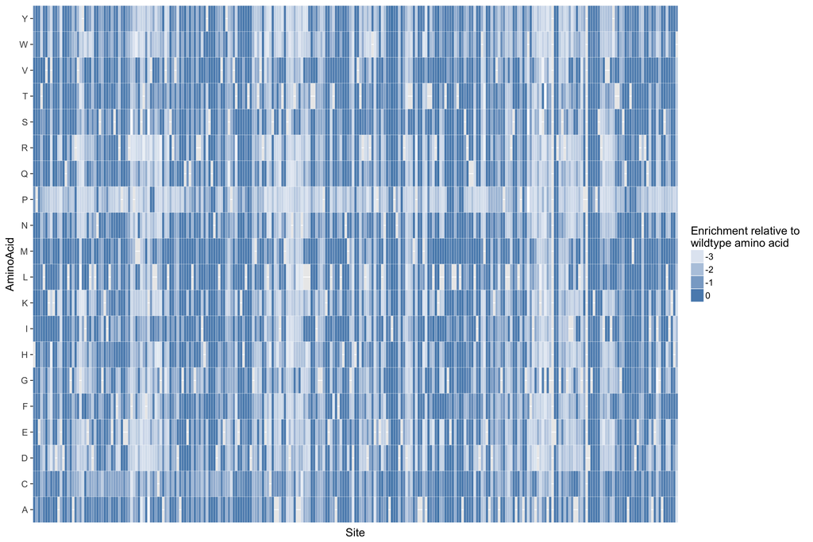

```r
base_size <- 15
p <- ggplot(df, aes(Site, AminoAcid)) + geom_tile(aes(fill = Trial_1_AmpConc_2500),colour = "white") + scale_fill_gradient(low = "white",high = "steelblue") + guides(fill = guide_legend(title = "Enrichment relative to \nwildtype amino acid"))
p = p + theme_grey(base_size = base_size) + scale_x_discrete(expand = c(0, 0)) + scale_y_discrete(expand = c(0, 0))
p
```

[`phydms`](http://jbloomlab.github.io/phydms/phydms_prog.html) uses *amino-acid preferences* rather than *enrichment scores*. We can transform these log enrichment scores to amino-acid preferences by normalizing the exponentiation of the scores for each site. Below are the first few sites and amino acids of the resulting preferences. Notice that the numbering has changed from above. In [`phydms`](http://jbloomlab.github.io/phydms/phydms_prog.html) a site is numbered in relation to the first site in the preferences rather than to the start codon.

```python
import pandas as pd
df = pd.read_csv("example_data/betaLactamase_enrichmentScores.csv")
minenrichment = 1.0e-4 # minimum allowed enrichment
df["preference"] = [max(minenrichment, (10**df["Trial_1_AmpConc_2500"][x] + 10**df["Trial_1_AmpConc_2500"][x])/2) for x in range(len(df))]
df = df.pivot(index = "Site", columns = "AminoAcid", values = "preference")
df.fillna(1, inplace = True)
df = df.div(df.sum(axis=1), axis=0)
df.insert(0, "site", range(1,len(df)+1))
df.to_csv("example_data/betaLactamase_prefs.csv", index = False)
print df.iloc[:,:9].head(6).to_string(index = False)
```

```
site         A         C         D         E         F         G         H         I

   1  0.070118  0.033902  0.049391  0.044621  0.022678  0.063982  0.070727  0.036060
   2  0.002058  0.035362  0.057655  0.078354  0.040415  0.012446  0.070924  0.049739
   3  0.057806  0.042278  0.050113  0.059354  0.048054  0.068718  0.063015  0.043187
   4  0.013668  0.004088  0.003170  0.002596  0.001298  0.001802  0.005931  0.177391
   5  0.066102  0.004275  0.000273  0.002788  0.027495  0.003923  0.025634  0.105117
   6  0.056257  0.048057  0.056197  0.070021  0.042867  0.054567  0.048590  0.047577
```

We can visualize the preferences as a logoplot using [phydms_logoplot](http://jbloomlab.github.io/phydms/phydms_logoplot.html):

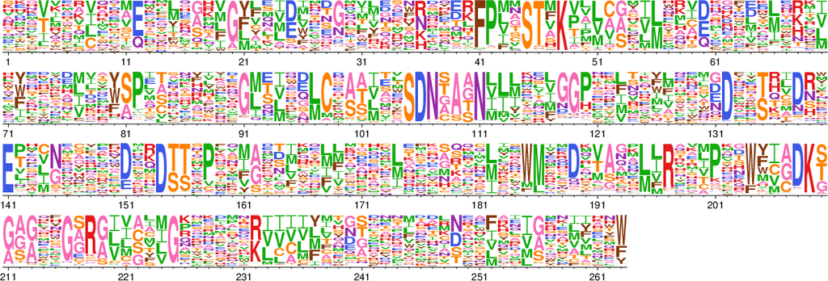

For more information on the preference file formats, please see the [full `phydms` documentation](http://jbloomlab.github.io/phydms/phydms_prog.html). For more detailed information on transforming enrichment scores into amino-acid preferences, please see [`dms_tools`: Algorithm to infer site-specific preferences](http://jbloomlab.github.io/dms_tools/inferprefs_algorithm.html).

### Sequences

We will use an alignment of $\beta$-lactamase sequences. It is important to note there is exactly the same number of preferences as sites in the alignment.

```
Sequences read from: example_data/betaLactamase_alignment.fasta
There are 50 sequences
Each sequence is 263 amino acids long
Preferences read from: example_data/betaLactamase_prefs.csv
There are preferences measured for 263 sites
```

You can use the [`phydms`](http://jbloomlab.github.io/phydms/phydms_prog.html) auxiliary program [`phydms_prepalignment`](http://jbloomlab.github.io/phydms/phydms_prepalignment.html) to filter your sequences and prepare an alignment for [`phydms_comprehensive`](http://jbloomlab.github.io/phydms/phydms_comprehensive_prog.html).

### `phydms_comprehensive`

We can now run [`phydms_comprehensive`](http://jbloomlab.github.io/phydms/phydms_comprehensive_prog.html) by specifying our output prefix (in this case a directory called `betaLactamase`), our preferences, and our alignment. The output below is the [`phydms_comprehensive`](http://jbloomlab.github.io/phydms/phydms_comprehensive_prog.html) run log.

```bash
phydms_comprehensive betaLactamase/ example_data/betaLactamase_alignment.fasta example_data/betaLactamase_prefs.csv --raxml raxml
```

```
2018-01-24 21:46:20,943 - INFO - Beginning execution of phydms_comprehensive in directory /Users/sarah/Desktop/phydms/tutorial

2018-01-24 21:46:20,943 - INFO - Progress is being logged to betaLactamase/log.log

2018-01-24 21:46:20,943 - INFO - Version information:
    Time and date: Wed Jan 24 21:46:20 2018
    Platform: Darwin-15.6.0-x86_64-i386-64bit
    Python version: 3.5.2 (v3.5.2:4def2a2901a5, Jun 26 2016, 10:47:25)  [GCC 4.2.1 (Apple Inc. build 5666) (dot 3)]
    phydms version: 2.2.dev1
    Bio version: 1.68
    cython version: 0.27.3
    numpy version: 1.13.3
    scipy version: 0.19.0
    matplotlib version: 2.0.2
    natsort version: 5.1.1
    sympy version: 1.0
    six version: 1.10.0
    pandas version: 0.20.3
    pyvolve version: 0.8.4
    statsmodels version: 0.8.0
    weblogolib version: 3.5.0
    PyPDF2 version: 1.26.0

2018-01-24 21:46:20,943 - INFO - Parsed the following command-line arguments:
    randprefs = False
    noavgprefs = False
    raxml = raxml
    outprefix = betaLactamase/
    prefsfiles = ['example_data/betaLactamase_prefs.csv']
    alignment = example_data/betaLactamase_alignment.fasta
    omegabysite = False
    gammaomega = False
    diffprefsbysite = False
    gammabeta = False
    brlen = optimize
    tree = None
    ncpus = -1

2018-01-24 21:46:20,944 - INFO - Checking that the alignment example_data/betaLactamase_alignment.fasta is valid...
2018-01-24 21:46:21,150 - INFO - Valid alignment specifying 50 sequences of length 789.
```

[output cut: 28 more lines]

```
2018-01-24 22:03:07,584 - INFO - Analysis completed for ExpCM_betaLactamase_prefs
2018-01-24 22:03:07,584 - INFO - Found expected output file betaLactamase/ExpCM_betaLactamase_prefs_log.log
2018-01-24 22:03:07,584 - INFO - Found expected output file betaLactamase/ExpCM_betaLactamase_prefs_tree.newick
2018-01-24 22:03:07,585 - INFO - Found expected output file betaLactamase/ExpCM_betaLactamase_prefs_loglikelihood.txt
2018-01-24 22:03:07,585 - INFO - Found expected output file betaLactamase/ExpCM_betaLactamase_prefs_modelparams.txt
2018-01-24 22:03:07,585 - INFO - Analysis successful for ExpCM_betaLactamase_prefs

2018-01-24 22:05:44,594 - INFO - Analysis completed for averaged_ExpCM_betaLactamase_prefs
2018-01-24 22:05:44,594 - INFO - Found expected output file betaLactamase/averaged_ExpCM_betaLactamase_prefs_log.log
2018-01-24 22:05:44,594 - INFO - Found expected output file betaLactamase/averaged_ExpCM_betaLactamase_prefs_tree.newick
2018-01-24 22:05:44,595 - INFO - Found expected output file betaLactamase/averaged_ExpCM_betaLactamase_prefs_loglikelihood.txt
2018-01-24 22:05:44,595 - INFO - Found expected output file betaLactamase/averaged_ExpCM_betaLactamase_prefs_modelparams.txt
2018-01-24 22:05:44,595 - INFO - Analysis successful for averaged_ExpCM_betaLactamase_prefs

2018-01-24 22:05:45,612 - INFO - Successful completion of phydms_comprehensive
```

## Output files

[`phydms_comprehensive`](http://jbloomlab.github.io/phydms/phydms_comprehensive_prog.html) produces both the standard [`phydms`](http://jbloomlab.github.io/phydms/phydms_prog.html) output files for each model and a summary file. Please see the [full documentation](http://jbloomlab.github.io/phydms/phydms.html) for more information on the standard output files.

```bash
ls betaLactamase/*
```

```
betaLactamase/ExpCM_betaLactamase_prefs_log.log
betaLactamase/ExpCM_betaLactamase_prefs_loglikelihood.txt
betaLactamase/ExpCM_betaLactamase_prefs_modelparams.txt
betaLactamase/ExpCM_betaLactamase_prefs_tree.newick
betaLactamase/RAxML_bestTree.betaLactamase_alignment
betaLactamase/RAxML_tree.newick
betaLactamase/YNGKP_M0_log.log
betaLactamase/YNGKP_M0_loglikelihood.txt
betaLactamase/YNGKP_M0_modelparams.txt
betaLactamase/YNGKP_M0_tree.newick
betaLactamase/YNGKP_M5_log.log
betaLactamase/YNGKP_M5_loglikelihood.txt
betaLactamase/YNGKP_M5_modelparams.txt
betaLactamase/YNGKP_M5_tree.newick
betaLactamase/averaged_ExpCM_betaLactamase_prefs_log.log
betaLactamase/averaged_ExpCM_betaLactamase_prefs_loglikelihood.txt
betaLactamase/averaged_ExpCM_betaLactamase_prefs_modelparams.txt
betaLactamase/averaged_ExpCM_betaLactamase_prefs_tree.newick
betaLactamase/log.log
betaLactamase/modelcomparison.md
betaLactamase/ramxl_output.txt
betaLactamase/raxml_output.txt
```

## Interpretation of `phydms_comprehensive` results

To compare the *ExpCM* with $\beta$-lactamase deep mutational scanning data to the *YNGKP* family we can look at the summary file `modelcomparison.md`.

| Model | deltaAIC | LogLikelihood | nParams | ParamValues |
| --- | --- | --- | --- | --- |
| ExpCM_betaLactamase_prefs | 0.00 | -2592.16 | 6 | beta=1.36, kappa=2.64, omega=0.69 |
| YNGKP_M5 | 717.42 | -2944.87 | 12 | alpha_omega=0.30, beta_omega=0.49, kappa=3.02 |
| averaged_ExpCM_betaLactamase_prefs | 794.48 | -2989.40 | 6 | beta=0.82, kappa=2.36, omega=0.28 |
| YNGKP_M0 | 819.26 | -2996.79 | 11 | kappa=2.39, omega=0.28 |

**First, we can see the *ExpCM* has the largest log-likelihood of all four of the models.** It significantly outperforms (evaluated by the $\Delta$AIC) the non-site-specific *YNGKP* models. It also outperforms the *ExpCM* control where the preferences are averaged across the sites rendering the model non-site-specific. **These comparisons are evidence that the *ExpCM* model informed by the deep mutational scanning results describes the natural evolution of $\beta$-lactamase better than traditional, non-site-specific models.**

We can also evaluate the amino-acid preferences by the value of the *ExpCM* stringency parameter, $\beta$. $\beta$ is a way to gauge how well the selection in the lab compares to selection in nature. When $\beta$ is fit to be greater than $1$ it means the selection in nature prefers the same amino acids but with a greater stringency. The converse is true when $\beta$ is less than $1$. When our preferences are re-scaled with a $\beta>1$, we see the strongly preferred amino acids “grow” while the weakly preferred amino acids “shrink”.

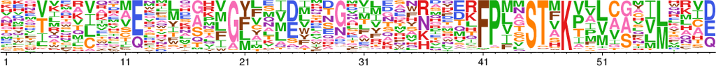

Above is a snippet of the $\beta$-lactamase preferences without scaling by $\beta$

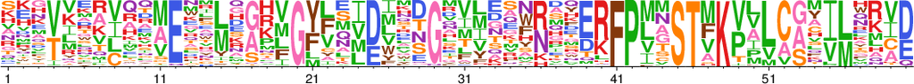

Above is a snippet of the $\beta$-lactamase preferences scaled by $\beta = 3$

When $\beta=0$, the heights become uniform and the *ExpCM* loses all of its site-specific information.

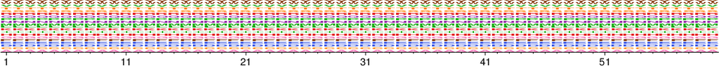

In the $\beta$-lactamase example, $\beta$ is fit to be $1.36$. **Since this number is close to $1$, we can conclude that not only is the *ExpCM* with amino-acid preferences a better description of natural sequence evolution than non-site specific models but that natural evolution prefers the same amino acids that are preferred in the experiment, but with slightly greater stringency.** For more information on scaling amino-acid preferences by $\beta$, please see [Bloom, 2014](http://research.fhcrc.org/content/dam/stripe/bloom/labfiles/publications/Bloom2014b.pdf).

Please see the [full documentation](http://jbloomlab.github.io/phydms/index.html) if you would like to learn more about the [`phydms_comprehensive`](http://jbloomlab.github.io/phydms/phydms_comprehensive_prog.html) program and its other options.

# Comparing two `DMS` datasets for the same protein

If you perform a deep mutational scanning experiment multiple times under slightly different experimental conditions, you may want to compare how well each dataset explains natural sequence variation. These experimental differences could be in how the variant libraries were generated, how the selection pressure was exerted, etc. We can use [`phydms_comprehensive`](http://jbloomlab.github.io/phydms/phydms_comprehensive_prog.html) to compare *ExpCM* models with two or more different sets of preferences to both the *YNGKP* family of models and to each other.

For this [`phydms_comprehensive`](http://jbloomlab.github.io/phydms/phydms_comprehensive_prog.html) analysis, you will need multiple sets of amino-acid preferences for the same protein from your deep mutational scanning experiments and a codon-level sequence alignment of your gene. [`phydms_comprehensive`](http://jbloomlab.github.io/phydms/phydms_comprehensive_prog.html) will then

• infer a tree using [`RAxML`](http://sco.h-its.org/exelixis/software.html)  
• run [`phydms`](http://jbloomlab.github.io/phydms/phydms_prog.html) with the *YNGKP_M0*, the *YNKGP_M5* and the *ExpCM* (with and without averaged preferences) for each set of preferences  
• summarize the results

See the [full documentation](http://jbloomlab.github.io/phydms/index.html) for specifics on these models or the [`phydms_comprehensive`](http://jbloomlab.github.io/phydms/phydms_comprehensive_prog.html) program.

We are going to walk through an example of [`phydms_comprehensive`](http://jbloomlab.github.io/phydms/phydms_comprehensive_prog.html) and compare *ExpCM*s with amino-acid preferences for the influenza virus protein hemagglutinin described in [Thyagarajan and Bloom, 2014](http://research.fhcrc.org/content/dam/stripe/bloom/labfiles/publications/ThyagarajanAndBloom2014.pdf) and [Doud and Bloom, 2016](http://www.mdpi.com/1999-4915/8/6/155).

## `phydms_comprehensive` command-line usage

Here is the full list of requirements and options for [`phydms_comprehensive`](http://jbloomlab.github.io/phydms/phydms_comprehensive_prog.html). Below is a discussion of the input files, running the `phydms_comprehensive` command, and interpretation of the results.

```bash
phydms_comprehensive -h
```

```
usage: phydms_comprehensive [-h] (--raxml RAXML | --tree TREE) [--ncpus NCPUS]
                            [--brlen {scale,optimize}] [--omegabysite]
                            [--diffprefsbysite] [--gammaomega] [--gammabeta]
                            [--no-avgprefs] [--randprefs] [-v]
                            outprefix alignment prefsfiles [prefsfiles ...]

Comprehensive phylogenetic model comparison and detection of selection
informed by deep mutational scanning data. This program runs 'phydms'
repeatedly to compare substitution models and detect selection. The 'phydms'
package is written by the Bloom lab (see
https://github.com/jbloomlab/phydms/contributors). Version 2.2.dev1. Full
documentation at http://jbloomlab.github.io/phydms

positional arguments:
  outprefix             Output file prefix.
  alignment             Existing FASTA file with aligned codon sequences.
  prefsfiles            Existing files with site-specific amino-acid
                        preferences.

optional arguments:
  -h, --help            show this help message and exit
  --raxml RAXML         Path to RAxML (e.g., 'raxml') (default: None)
  --tree TREE           Existing Newick file giving input tree. (default:
                        None)
  --ncpus NCPUS         Use this many CPUs; -1 means all available. (default:
                        -1)
  --brlen {scale,optimize}
                        How to handle branch lengths: scale by single
                        parameter or optimize each one (default: optimize)
  --omegabysite         Fit omega (dN/dS) for each site. (default: False)
  --diffprefsbysite     Fit differential preferences for each site. (default:
                        False)
  --gammaomega          Fit ExpCM with gamma distributed omega. (default:
                        False)
  --gammabeta           Fit ExpCM with gamma distributed beta. (default:
                        False)
  --no-avgprefs         No fitting of models with preferences averaged across
                        sites for ExpCM. (default: False)
  --randprefs           Include ExpCM models with randomized preferences.
                        (default: False)
  -v, --version         show program's version number and exit
```

## Input Files

This example uses the following files: `HA_prefs_Thyagarajan.csv`, `HA_prefs_Doud.csv`, and `HA_alignment.fasta`.

### Amino-acid preferences

The HA amino-acid preferences from [Thyagarajan and Bloom, 2014](http://research.fhcrc.org/content/dam/stripe/bloom/labfiles/publications/ThyagarajanAndBloom2014.pdf) and [Doud and Bloom, 2016](http://www.mdpi.com/1999-4915/8/6/155) were measured using two different library construction strategies. (Please see [Thyagarajan and Bloom, 2014](http://research.fhcrc.org/content/dam/stripe/bloom/labfiles/publications/ThyagarajanAndBloom2014.pdf) and [Doud and Bloom, 2016](http://www.mdpi.com/1999-4915/8/6/155) for more information on the reverse-genetics strategy and the helper virus strategy respectively). We would like to know if one set of preferences significantly changes the behavior of the *ExpCM* compared to the other set or the average of the two sets.

We can compare the amino-acid preference measurements found in `HA_prefs_Thyagarajan.csv` and `HA_prefs_Doud.csv` using [`phydms_logoplots`](http://jbloomlab.github.io/phydms/phydms_logoplot.html):

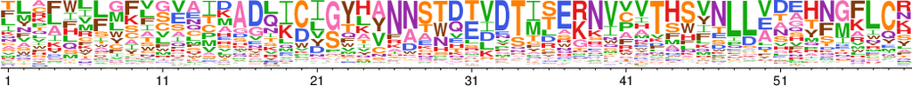

HA_prefs_Thyagarajan

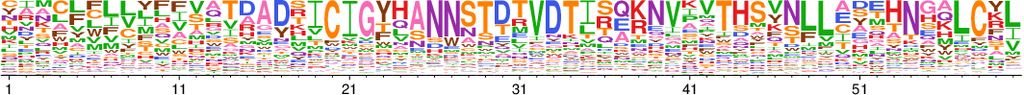

HA_prefs_Doud

As we would expect, the preferences measured from the two experiments are similar but not identical.

For more information on how to change *enrichment scores* to *amino-acid preferences*, please see the Comparing your `DMS` data to natural sequence evolution section of this tutorial. For more information on the preference file formats, please see the [full `phydms` documentation](http://jbloomlab.github.io/phydms/phydms_prog.html) or an example in the Comparing your `DMS` data to natural sequence evolution section of this tutorial.

### Sequences

We will use an alignment of HA sequences. It is important to note there is exactly the same number of preferences in each preference file as sites in the alignment.

```
Sequences read from: example_data/HA_alignment.fasta
There are 34 sequences
Each sequence is 564 amino acids long

Preferences read from: example_data/HA_prefs_Doud.csv
There are preferences measured for 564 sites
Preferences read from: example_data/HA_prefs_Thyagarajan.csv
There are preferences measured for 564 sites
```

You can use the [`phydms`](http://jbloomlab.github.io/phydms/phydms_prog.html) auxiliary program [`phydms_prepalignment`](http://jbloomlab.github.io/phydms/phydms_prepalignment.html) to filter your sequences and prepare an alignment for [`phydms_comprehensive`](http://jbloomlab.github.io/phydms/phydms_comprehensive_prog.html).

### `phydms_comprehensive`

We can now run [`phydms_comprehensive`](http://jbloomlab.github.io/phydms/phydms_comprehensive_prog.html) by specifying our output prefix (in this case a directory called `HA`), our preferences, and our alignment.

```bash
phydms_comprehensive HA/ example_data/HA_alignment.fasta example_data/HA_prefs_Thyagarajan.csv example_data/HA_prefs_Doud.csv --raxml raxml
```

## Output files

[`phydms_comprehensive`](http://jbloomlab.github.io/phydms/phydms_comprehensive_prog.html) produces both the standard [`phydms`](http://jbloomlab.github.io/phydms/phydms_prog.html) output files for each model and a summary file. See the the Comparing your `DMS` data to natural sequence evolution section of the tutorial for an example and [full `phydms` documentation](http://jbloomlab.github.io/phydms/phydms.html) for more information on the standard output files.

## Interpretation of `phydms_comprehensive` results

To compare the *ExpCM* with the different preferences, we can look at the summary file `modelcomparison.md`.

| Model | deltaAIC | LogLikelihood | nParams | ParamValues |
| --- | --- | --- | --- | --- |
| ExpCM_HA_prefs_Doud | 0.00 | -4877.65 | 6 | beta=2.11, kappa=5.14, omega=0.52 |
| ExpCM_HA_prefs_Thyagarajan | 44.18 | -4899.74 | 6 | beta=1.72, kappa=4.94, omega=0.55 |
| averaged_ExpCM_HA_prefs_Doud | 2090.58 | -5922.94 | 6 | beta=0.68, kappa=5.36, omega=0.22 |
| averaged_ExpCM_HA_prefs_Thyagarajan | 2097.86 | -5926.58 | 6 | beta=0.31, kappa=5.36, omega=0.22 |
| YNGKP_M5 | 2113.50 | -5928.40 | 12 | alpha_omega=0.30, beta_omega=1.42, kappa=4.68 |
| YNGKP_M0 | 2219.64 | -5982.47 | 11 | kappa=4.61, omega=0.20 |

First, we can see that both *ExpCM* models all have significantly larger (evaluated by the $\Delta$AIC) log-likelihoods than the two *ExpCM* with averaged preferences. These, in turn, have significantly larger log-likelihoods than the *YNGKP* family. **Second, we can see the *ExpCM* with the preferences from [Doud and Bloom, 2016](http://www.mdpi.com/1999-4915/8/6/155) has a larger log-likelihood than then *ExpCM* with the [Thyagarajan and Bloom, 2014](http://research.fhcrc.org/content/dam/stripe/bloom/labfiles/publications/ThyagarajanAndBloom2014.pdf) preferences.**

These comparisons are evidence that the *ExpCM* with the [Doud and Bloom, 2016](http://www.mdpi.com/1999-4915/8/6/155) preferences is a better description of natural sequence evolution than the *ExpCM* with the [Thyagarajan and Bloom, 2014](http://research.fhcrc.org/content/dam/stripe/bloom/labfiles/publications/ThyagarajanAndBloom2014.pdf) preferences or either one of the non-site-specific models.

Please see the [full documentation](http://jbloomlab.github.io/phydms/index.html) if you would like to learn more about the [`phydms_comprehensive`](http://jbloomlab.github.io/phydms/phydms_comprehensive_prog.html) program and its other options.

# Detecting Diversifying Selection

A deep mutational scanning experiment measures the amino-acid preferences of a given protein for a given selection pressure. However, it is not expected that the selection in lab faithfully describes the selection a protein faces in nature. We can use [`phydms_comprehensive`](http://jbloomlab.github.io/phydms/phydms_comprehensive_prog.html) and the flag `--omegabysite` to identify sites which deviate from the *ExpCM* model via an unexpectedly high or low rate of amino-acid substitution. That is, we will be able to differentiate between sites which are under *diversifying selection*, a high rate, and sites which are under a selective constraint not measured in lab, a low rate. This is in contrast to differential selection, which selects for unexpected amino-acid substitutions rather than unexpected rates.

For more information on the exact procedure, please see the [full documentation](http://jbloomlab.github.io/phydms/ExpCM.html#identifying-diversifying-selection-via-site-specific-values) or [Bloom, 2017](http://research.fhcrc.org/content/dam/stripe/bloom/labfiles/publications/Bloom2017.pdf). This procedure is analogous to the [FEL method](http://www.datamonkey.org/help/fel.php) described by [Pond and Frost, 2005](https://academic.oup.com/bioinformatics/article/21/5/676/220389/HyPhy-hypothesis-testing-using-phylogenies).

We are going to walk through an example of [`phydms_comprehensive`](http://jbloomlab.github.io/phydms/phydms_comprehensive_prog.html) to detect sites under diversifying selection in influenza virus protein hemagglutinin using the preferences measured [Doud and Bloom, 2016](http://www.mdpi.com/1999-4915/8/6/155) and in $\beta$-lactamase using the preferences measured by [Stiffler *et al*, 2015](http://www.sciencedirect.com/science/article/pii/S0092867415000781).

## `phydms_comprehensive` command-line usage

Here is the full list of requirements and options for [`phydms_comprehensive`](http://jbloomlab.github.io/phydms/phydms_comprehensive_prog.html). To detect diversifying pressure, we are going to include the optional flag `--omegabysite`. Below is a discussion of the input files, running the `phydms_comprehensive` command, and interpretation of the results.

```bash
phydms_comprehensive -h
```

```
usage: phydms_comprehensive [-h] (--raxml RAXML | --tree TREE) [--ncpus NCPUS]
                            [--brlen {scale,optimize}] [--omegabysite]
                            [--diffprefsbysite] [--gammaomega] [--gammabeta]
                            [--no-avgprefs] [--randprefs] [-v]
                            outprefix alignment prefsfiles [prefsfiles ...]

Comprehensive phylogenetic model comparison and detection of selection
informed by deep mutational scanning data. This program runs 'phydms'
repeatedly to compare substitution models and detect selection. The 'phydms'
package is written by the Bloom lab (see
https://github.com/jbloomlab/phydms/contributors). Version 2.2.dev1. Full
documentation at http://jbloomlab.github.io/phydms

positional arguments:
  outprefix             Output file prefix.
  alignment             Existing FASTA file with aligned codon sequences.
  prefsfiles            Existing files with site-specific amino-acid
                        preferences.

optional arguments:
  -h, --help            show this help message and exit
  --raxml RAXML         Path to RAxML (e.g., 'raxml') (default: None)
  --tree TREE           Existing Newick file giving input tree. (default:
                        None)
  --ncpus NCPUS         Use this many CPUs; -1 means all available. (default:
                        -1)
  --brlen {scale,optimize}
                        How to handle branch lengths: scale by single
                        parameter or optimize each one (default: optimize)
  --omegabysite         Fit omega (dN/dS) for each site. (default: False)
  --diffprefsbysite     Fit differential preferences for each site. (default:
                        False)
  --gammaomega          Fit ExpCM with gamma distributed omega. (default:
                        False)
  --gammabeta           Fit ExpCM with gamma distributed beta. (default:
                        False)
  --no-avgprefs         No fitting of models with preferences averaged across
                        sites for ExpCM. (default: False)
  --randprefs           Include ExpCM models with randomized preferences.
                        (default: False)
  -v, --version         show program's version number and exit
```

## Input Files

A full discussion of the amino-acid preferences and sequences for $\beta$-lacatamse and HA can be found in the earlier sections of this tutorial. Briefly,

```
BetaLactamase
Sequences read from: example_data/betaLactamase_alignment.fasta
There are 50 sequences
Each sequence is 263 amino acids long
Preferences read from: example_data/betaLactamase_prefs.csv
There are preferences measured for 263 sites

HA
Sequences read from: example_data/HA_alignment.fasta
There are 34 sequences
Each sequence is 564 amino acids long
Preferences read from: example_data/HA_prefs_Doud.csv
There are preferences measured for 564 sites
```

### `phydms_comprehensive`

We can now run [`phydms_comprehensive`](http://jbloomlab.github.io/phydms/phydms_comprehensive_prog.html) by specifying our output prefix (in this case a directory called `HA_omegabysite` or `betaLactmase_omegabysite`), our preferences, our alignment and the flag `--omegabysite`. Each alignment requires its own [`phydms_comprehensive`](http://jbloomlab.github.io/phydms/phydms_comprehensive_prog.html) run.

```bash
phydms_comprehensive HA_omegabysite/ example_data/HA_alignment.fasta example_data/HA_prefs_Doud.csv --raxml raxml --omegabysite

phydms_comprehensive betaLactamase_omegabysite/ example_data/betaLactamase_alignment.fasta example_data/betaLactamase_prefs.csv --raxml raxml --omegabysite
```

## Output files

[`phydms_comprehensive`](http://jbloomlab.github.io/phydms/phydms_comprehensive_prog.html) produces both the standard [`phydms`](http://jbloomlab.github.io/phydms/phydms_prog.html) output files for each model and a summary file. See the Comparing your `DMS` data to natural sequence evolution section of the tutorial for an example and the [full `phydms` documentation](http://jbloomlab.github.io/phydms/phydms.html) for more information on the standard output files.

## Interpretation of `phydms_comprehensive` results

To detect sites under diversifying selection, we can look at the summary files with the suffix `_omegabysite.txt`. First, we will look at the results from the HA analysis.

HA_omegabysite/ExpCM_HA_prefs_Doud_omegabysite.txt lists the site, the fitted $\omega_r$ value, the p-value for the hypothesis $H_0: \omega_r = 1$, the dLnL (difference in log-likelihood between *ExpCM* with $\omega_r = 1$ and the *ExpCM* with the fitted $\omega_r$ value), and the Q-value, which controls for multiple comparisons via the false discovery rate. For more information on these metrics, please see the [full `phydms_comprehensive` documentation](http://jbloomlab.github.io/phydms/phydms_prog.html#site-specific-omega-file). The sites are sorted by the p-value which means the sites with the strongest evidence for deviations from $\omega_r = 1$ will be at the top of the file.

```bash
head -n 20 HA_omegabysite/ExpCM_HA_prefs_Doud_omegabysite.txt
```

```
# Omega fit to each site after fixing tree and all other parameters.
# Fits compared to null model of omega = 1.
# P-values NOT corrected for multiple testing, so consider Q-values too.
# Q-values computed separately for omega > and < 1 # Will fit different synonymous rate for each site.
#
site    omega   P   dLnL    Q
277 0.000   0.00246 4.585   0.694
147 0.000   0.00184 4.853   0.694
1   1.000   1   0.000   1
373 1.000   1   0.000   1
374 0.000   0.4 0.353   1
375 0.000   0.284   0.574   1
376 1.000   1   0.000   1
377 1.000   1   0.000   1
378 0.000   0.523   0.204   1
380 1.000   1   0.000   1
372 0.000   0.507   0.220   1
381 0.000   0.975   0.000   1
382 0.000   0.456   0.278   1
383 1.000   1   0.000   1
```

and sites with the weakest evidence for deviation from $\omega_r = 1$ will be at the bottom of the file.

```bash
tail -n 20 HA_omegabysite/ExpCM_HA_prefs_Doud_omegabysite.txt
```

```
204 0.356   0.292   0.554   1
141 100.000 0.0783  1.550   1
195 1.000   1   0.000   1
193 0.000   0.618   0.125   1
179 1.000   0.999   0.000   1
180 1.000   1   0.000   1
181 0.455   0.585   0.149   1
182 1.000   1   0.000   1
183 0.462   0.428   0.314   1
184 1.820   0.633   0.114   1
194 100.000 0.152   1.027   1
185 1.306   0.797   0.033   1
187 1.000   1   0.000   1
188 1.000   1   0.000   1
189 1.000   1   0.000   1
190 0.000   0.0538  1.860   1
191 0.000   0.686   0.081   1
192 1.000   1   0.000   1
186 1.000   1   0.000   1
564 0.000   0.472   0.259   1
```

Here are the sites in $\beta$-lactamase with the strongest evidence for deviations from $\omega_r = 1$

```bash
head -n 20 betaLactamase_omegabysite/ExpCM_betaLactamase_prefs_omegabysite.txt
```

```
# Omega fit to each site after fixing tree and all other parameters.
# Fits compared to null model of omega = 1.
# P-values NOT corrected for multiple testing, so consider Q-values too.
# Q-values computed separately for omega > and < 1 # Will fit different synonymous rate for each site.
#
site    omega   P   dLnL    Q
248 20.043  0.000567    5.941   0.0745
213 37.250  0.000345    6.404   0.0745
218 95.530  0.00262 4.527   0.23
233 0.000   0.00164 4.956   0.432
139 33.371  0.0112  3.215   0.738
134 0.000   0.0133  3.064   0.875
146 0.000   0.00988 3.328   0.875
87  0.029   0.0102  3.299   0.875
257 0.000   0.0169  2.853   0.889
209 100.000 0.0175  2.823   0.92
105 72.028  0.0286  2.396   0.951
15  100.000 0.0326  2.284   0.951
141 100.000 0.0307  2.334   0.951
46  82.846  0.0218  2.629   0.951
```

We can see in both examples there is a small subset of sites which deviate display a faster ($\omega_r>1$) or slower ($\omega_r <1$) than expected rate of amino-acid substitutions.

# Detecting Differential Selection

A deep mutational scanning experiment measures the amino-acid preferences of a given protein for a given selection pressure. However, it is not expected that the selection in lab faithfully describes the selection a protein faces in nature. We can use [`phydms_comprehensive`](http://jbloomlab.github.io/phydms/phydms_comprehensive_prog.html) and the flag `--diffprefsbysite` to identify sites which deviate from the *ExpCM* model via *differential selection*. In contrast to diversifying selection, differential selection leads to unexpected amino-acid substitutions rather than unexpected rates.

For more information on the exact procedure, please see the [full documentation](http://jbloomlab.github.io/phydms/ExpCM.html#identifying-differentially-selected-amino-acids-by-fitting-preferences-for-each-site) or [Bloom, 2017](http://research.fhcrc.org/content/dam/stripe/bloom/labfiles/publications/Bloom2017.pdf).

We are going to walk through an example of [`phydms_comprehensive`](http://jbloomlab.github.io/phydms/phydms_comprehensive_prog.html) to detect sites under differential selection in influenza virus protein hemagglutinin using the preferences measured [Doud and Bloom, 2016](http://www.mdpi.com/1999-4915/8/6/155) and in $\beta$-lactamase using the preferences measured by [Stiffler *et al*, 2015](http://www.sciencedirect.com/science/article/pii/S0092867415000781).

## `phydms_comprehensive` command-line usage

```bash
phydms_comprehensive -h
```

```
usage: phydms_comprehensive [-h] (--raxml RAXML | --tree TREE) [--ncpus NCPUS]
                            [--brlen {scale,optimize}] [--omegabysite]
                            [--diffprefsbysite] [--gammaomega] [--gammabeta]
                            [--no-avgprefs] [--randprefs] [-v]
                            outprefix alignment prefsfiles [prefsfiles ...]

Comprehensive phylogenetic model comparison and detection of selection
informed by deep mutational scanning data. This program runs 'phydms'
repeatedly to compare substitution models and detect selection. The 'phydms'
package is written by the Bloom lab (see
https://github.com/jbloomlab/phydms/contributors). Version 2.2.dev1. Full
documentation at http://jbloomlab.github.io/phydms

positional arguments:
  outprefix             Output file prefix.
  alignment             Existing FASTA file with aligned codon sequences.
  prefsfiles            Existing files with site-specific amino-acid
                        preferences.

optional arguments:
  -h, --help            show this help message and exit
  --raxml RAXML         Path to RAxML (e.g., 'raxml') (default: None)
  --tree TREE           Existing Newick file giving input tree. (default:
                        None)
  --ncpus NCPUS         Use this many CPUs; -1 means all available. (default:
                        -1)
  --brlen {scale,optimize}
                        How to handle branch lengths: scale by single
                        parameter or optimize each one (default: optimize)
  --omegabysite         Fit omega (dN/dS) for each site. (default: False)
  --diffprefsbysite     Fit differential preferences for each site. (default:
                        False)
  --gammaomega          Fit ExpCM with gamma distributed omega. (default:
                        False)
  --gammabeta           Fit ExpCM with gamma distributed beta. (default:
                        False)
  --no-avgprefs         No fitting of models with preferences averaged across
                        sites for ExpCM. (default: False)
  --randprefs           Include ExpCM models with randomized preferences.
                        (default: False)
  -v, --version         show program's version number and exit
```

## Input Files

A full discussion of the amino-acid preferences and sequences for $\beta$-lacatamse and HA can be found in the earlier sections of this tutorial. Briefly,

```
BetaLactamase
Sequences read from: example_data/betaLactamase_alignment.fasta
There are 50 sequences
Each sequence is 263 amino acids long
Preferences read from: example_data/betaLactamase_prefs.csv
There are preferences measured for 263 sites

HA
Sequences read from: example_data/HA_alignment.fasta
There are 34 sequences
Each sequence is 564 amino acids long
Preferences read from: example_data/HA_prefs_Doud.csv
There are preferences measured for 564 sites
```

### `phydms_comprehensive`

We can now run [`phydms_comprehensive`](http://jbloomlab.github.io/phydms/phydms_comprehensive_prog.html) by specifying our output prefix (in this case a directory called `HA_diffprefs` or `betaLactmase_diffprefs`), our preferences, our alignment and the flag `--diffprefsbysite`. Each alignment requires its own [`phydms_comprehensive`](http://jbloomlab.github.io/phydms/phydms_comprehensive_prog.html) run.

```bash
phydms_comprehensive HA_diffprefs/ example_data/HA_alignment.fasta example_data/HA_prefs_Doud.csv --raxml raxml --diffprefsbysite

phydms_comprehensive betaLactamase_diffprefs/ example_data/betaLactamase_alignment.fasta example_data/betaLactamase_prefs.csv --raxml raxml --diffprefsbysite
```

## Output files

[`phydms_comprehensive`](http://jbloomlab.github.io/phydms/phydms_comprehensive_prog.html) produces both the standard [`phydms`](http://jbloomlab.github.io/phydms/phydms_prog.html) output files for each model and a summary file. See the Comparing your `DMS` data to natural sequence evolution section of the tutorial for an example and the [full `phydms` documentation](http://jbloomlab.github.io/phydms/phydms.html) for more information on the standard output files.

## Interpretation of `phydms_comprehensive` results

To detect sites under differential selection, we can look at the summary files with the suffix `diffprefsbysite.txt`. First, we will look at the results from the HA analysis.

HA_diffprefs/ExpCM_HA_prefs_Doud_diffprefsbysite.txt lists the site, the differential preference for each amino acid, and half absolute sum of the differential preferences for that site. A large differential preference value means that substitutions to that amino acid were seen at that site in the alignment *more* often than expected given the *ExpCM* and the measured amino-acid preferences. The last column can be used as a summary of differential selection strength for a given site. Larger values indicate the site is being strongly deferentially selected. For more information on these metrics, please see the [full `phydms_comprehensive` documentation](http://jbloomlab.github.io/phydms/phydms_prog.html#site-specific-differential-selection).

Here are the sites (and a subset of the differential preferences) in HA with the strongest evidence for differential selection

```python
import pandas as pd
df = pd.read_csv("HA_diffprefs/ExpCM_HA_prefs_Doud_diffprefsbysite.txt", sep='\t', skiprows=(0,1,2))
print df.iloc[:,range(9) + [-1]].head(6).to_string(index = False)
```

```
site   dpi_A   dpi_C   dpi_D   dpi_E   dpi_F   dpi_G   dpi_H   dpi_I  half_sum_abs_dpi
 174 -0.0089 -0.0050 -0.0074 -0.0091 -0.0022 -0.0097 -0.0065 -0.0094            0.1958
 127 -0.0166 -0.0020 -0.0018 -0.0006  0.1702 -0.0137 -0.0054 -0.0226            0.1702
 171 -0.0148 -0.0001 -0.0166 -0.0147 -0.0003  0.1638 -0.0028 -0.0159            0.1638
 277 -0.0072 -0.0030 -0.0051 -0.0182 -0.0025  0.1633 -0.0042 -0.0092            0.1633
   9 -0.0123  0.1620 -0.0031 -0.0022 -0.0074 -0.0068 -0.0087 -0.0152            0.1620
 496 -0.0079 -0.0040 -0.0054 -0.0098 -0.0049 -0.0092 -0.0076 -0.0117            0.1554
```

and sites with the weakest evidence

```python
import pandas as pd
df = pd.read_csv("HA_diffprefs/ExpCM_HA_prefs_Doud_diffprefsbysite.txt", sep='\t', skiprows=(0,1,2))
print df.iloc[:,range(9) + [-1]].tail(6).to_string(index = False)
```

```
site   dpi_A   dpi_C   dpi_D   dpi_E   dpi_F   dpi_G   dpi_H   dpi_I  half_sum_abs_dpi
 351 -0.0010 -0.0006 -0.0003 -0.0001  0.0068 -0.0012 -0.0001 -0.0014            0.0092
 327 -0.0001  0.0016 -0.0003 -0.0003  0.0003 -0.0010  0.0004 -0.0043            0.0088
 378  0.0000 -0.0000 -0.0000 -0.0000 -0.0000 -0.0000 -0.0000 -0.0000            0.0000
 342 -0.0000 -0.0000 -0.0000 -0.0000 -0.0000 -0.0000 -0.0000 -0.0000            0.0000
  73 -0.0000 -0.0000 -0.0000 -0.0000  0.0000 -0.0000 -0.0000  0.0000            0.0000
 283 -0.0000 -0.0000 -0.0000 -0.0000 -0.0000 -0.0000 -0.0000 -0.0000            0.0000
```

Here are the sites in $\beta$-lactamase with the strongest evidence for differential selection

```python
import pandas as pd
df = pd.read_csv("betaLactamase_diffprefs/ExpCM_betaLactamase_prefs_diffprefsbysite.txt", sep='\t', skiprows=(0,1,2))
print df.iloc[:,range(9) + [-1]].head(6).to_string(index = False)
```

```
site   dpi_A   dpi_C   dpi_D   dpi_E   dpi_F   dpi_G   dpi_H   dpi_I  half_sum_abs_dpi
 213 -0.3701 -0.0003 -0.0009 -0.0003 -0.0003 -0.5691 -0.0005 -0.0003            0.9656
 214 -0.0518 -0.0002 -0.0492 -0.0417  0.0032 -0.0533 -0.0048  0.0049            0.3394
 104 -0.0201 -0.0054 -0.0076 -0.0092 -0.0035 -0.0009 -0.0080 -0.0285            0.2555
 167 -0.0147 -0.0042 -0.0063 -0.0198 -0.0027 -0.0145 -0.0063 -0.0072            0.2271
  44 -0.0217 -0.0119 -0.0006 -0.0006 -0.0006 -0.0211 -0.0031  0.0429            0.2206
  90 -0.0187 -0.0024  0.1839 -0.0134 -0.0009 -0.0329 -0.0097 -0.0037            0.1839
```

We visualize the $\beta$-lactamase differential preferences for each site using [`phydms_logoplot`](http://jbloomlab.github.io/phydms/phydms_logoplot.html)

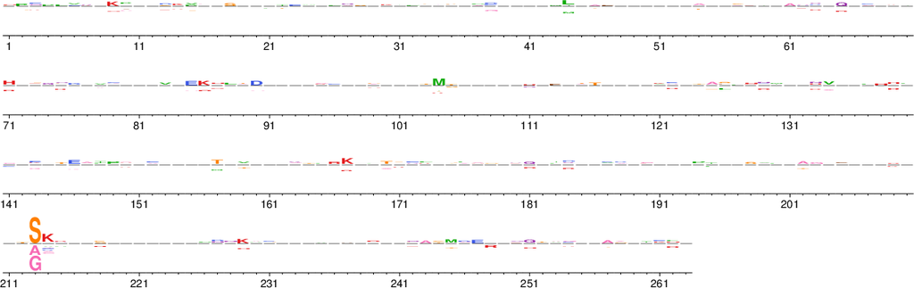

```bash
phydms_logoplot logoplots/betaLactamase_prefs_diff.pdf --mapmetric functionalgroup --colormap mapmetric --diffprefs betaLactamase_diffprefs/ExpCM_betaLactamase_prefs_diffprefsbysite.txt
```

We can see in both the HA and the $\beta$-lactamase example, there are a small subset of sites which appear to be under differential selection.